# Vit-Pytorch: Hierarchical Feature Distillation — Reproducibility & Deployment

Author

Gabriel François, Alban Géron, Léo Leroy, Marie Maignant, Siméon Tsang

Published

April 21, 2026

# 1 Introduction

## 1.1 Website overview

This website is the **reproducibility and deployment reference** for the *Dynamic Vision Transformer* (Dynamic-ViT) pipeline originally implemented by Gabriel François, Avner El Baz and Léo Leroy, inspired by Rao et al. (2021) and built on top of the standard ViT of Dosovitskiy et al. (2021). It was then augmented with an MAE-style self-supervised stage (He et al. 2022) and a semantic alignment stage (REPA) distilling features from a frozen DINOv2 backbone (Oquab et al. 2024).

The goal of this site is **not** to retrain the models from scratch — training the full pipeline on ImageNet-1k requires a multi-GPU setup that is incompatible with a Continuous Integration runner. Instead, this document:

- documents the project structure, its dependencies, and the configuration used;
- re-renders the figures and checkpoints produced by the training scripts so that readers can inspect the results without having a GPU;
- describes how to reproduce a **single forward pass** of the lightweight Student on any 128×128 RGB image, locally or from a fresh clone of the repo;
- acts as the public entry point for CI/CD (GitHub Actions auto-publishes this site on every push to the `reprod` branch).

**ImportantCaveats**

- **Training** the Teacher and Student models requires a CUDA-capable GPU with at least ~16 GB of VRAM and several hours of compute — it is **not** re-executed when this Quarto report is rendered.
- All figures below are loaded from `logs/imagenet/` and `checkpoints/public/imagenet/`, which are produced by the training scripts under `src/train/`.
- The dataset (ImageNet-1k 128×128, `benjamin-paine/imagenet-1k-128x128` on Hugging Face) is public but heavy (~30 GB); the inference demo at the end of this report only needs a handful of sample images, bundled in `data/images/`.

# 2 Environment and dependencies

## 2.1 Requirements

The code requires **Python 3.11+** and the dependencies pinned in `requirements.txt` and `pyproject.toml`. A CUDA-enabled build of PyTorch is strongly recommended for training; inference works on CPU.

**With uv (recommended)**

```bash
git clone https://github.com/<your-org>/Vit-Pytorch.git
cd Vit-Pytorch
uv sync
source .venv/bin/activate     # on Windows: .venv\Scripts\activate
```

**With pip + venv**

```bash
git clone https://github.com/<your-org>/Vit-Pytorch.git
cd Vit-Pytorch
python -m venv .venv
source .venv/bin/activate     # on Windows: .venv\Scripts\activate
pip install -r requirements.txt
```

A `.env` file is expected at the project root to redirect the Hugging Face dataset cache (the raw dataset is gitignored):

```bash
# .env
HF_DATASETS_CACHE=path/to/your/dataset_cache
```

The most relevant dependencies, extracted directly from `pyproject.toml`:

```python
import tomllib

with open(ROOT / "pyproject.toml", "rb") as f:
    pyproject = tomllib.load(f)

runtime = pyproject["project"]["dependencies"]
dev = pyproject["dependency-groups"]["dev"]

deps = pd.DataFrame({
    "package": runtime + dev,
    "group":   ["runtime"] * len(runtime) + ["dev"] * len(dev),
})
deps
```

|  | package | group |
| --- | --- | --- |
| 0 | numpy | runtime |
| 1 | tqdm | runtime |
| 2 | torch | runtime |
| 3 | torchinfo | runtime |
| 4 | torchvision | runtime |
| 5 | matplotlib | runtime |
| 6 | tensorboard | runtime |
| 7 | seaborn | runtime |
| 8 | scikit-learn | runtime |
| 9 | datasets[vision] | runtime |
| 10 | pytest | runtime |
| 11 | black | runtime |
| 12 | pylint | runtime |
| 13 | dotenv>=0.9.9 | runtime |
| 14 | pytest | dev |
| 15 | black | dev |
| 16 | isort | dev |
| 17 | pylint | dev |
| 18 | calflops | dev |
| 19 | transformers | dev |

## 2.2 Hardware recommendation

| Component | Training (full pipeline) | Inference only |
| --- | --- | --- |
| GPU | NVIDIA GPU, ≥ 16 GB VRAM (A100/V100/3090) | Not required (CPU works) |
| CUDA | 11.8 or 12.x | — |
| RAM | ≥ 32 GB | ≥ 4 GB |
| Disk | ~50 GB for the cached ImageNet-128×128 | ~200 MB for checkpoints + code |
| OS | Linux / macOS / Windows | Linux / macOS / Windows |

The reference runs underlying the figures of this report were executed on a single NVIDIA A100 GPU. Apple Silicon users can select the `mps` backend via `--device mps`; it is slower but functional for small batches.

# 3 Project structure

The repository follows a standard `cookiecutter`-like layout, with a clean separation between **code** (`src/`, `helper_function/`), **configuration** (`configs/`), **data plumbing** (`data/load/`), and **artefacts** (`logs/`, `checkpoints/`). Raw data is *never* committed.

```
Vit-Pytorch/
├── src/
│   ├── models/           # Architecture: ViT, DynamicViT, Patch Embed, Predictor LG
│   ├── train/            # Training loops: SSL teacher, REPA teacher, student
│   ├── test/             # Evaluation, FLOPs, MAE reconstruction quality
│   └── finetuning/       # LoRA fine-tuning scripts (STL-10)
├── configs/              # Hyper-parameters per dataset (ImageNet, CIFAR-10, STL-10)
├── data/
│   ├── load/             # HF dataset loaders (ImageNet, CIFAR, STL)
│   ├── raw/              # Local dataset cache (gitignored)
│   └── images/           # A few sample images for the website and inference demo
├── logs/                 # TensorBoard events and generated plots (committed)
├── checkpoints/
│   └── public/imagenet/  # Public .pth checkpoints served by this site
├── helper_function/      # LLRD, MAE helpers, colored logging, model loaders
├── .github/workflows/    # Quarto publish + Ruff CI
├── pyproject.toml        # Project metadata & dependencies (uv-compatible)
├── requirements.txt      # Pinned dependencies for pip
├── ruff.toml             # Linter configuration
├── _quarto.yml           # Quarto website configuration
├── index.qmd             # This report
└── LICENSE               # MIT License
```

The three main training scripts under `src/train/` (`train_teacher_SSL.py`, `train_teacher.py`, `train_student.py`) correspond to the three stages described in Section 4.3. The evaluation scripts in `src/test/` (`compare_st-te.py`, `parameters_computing.py`, `test_SSLteacher.py`) regenerate every figure displayed below.

# 4 Scientific content

## 4.1 Definitions

A Vision Transformer processes an image as a short sequence of patch tokens rather than a dense grid. Given an image $I \in \mathbb{R}^{H\times W\times C}$ splitted into $N = HW / p^2$ non-overlapping patches of side $p$, the model computes a sequence of $N+1$ $d$-dimensional tokens (including a learnable `[CLS]` token) and applies $L$ transformer blocks on top (Dosovitskiy et al. 2021).

Three concepts are central to our pipeline:

- **Masked Autoencoder (MAE).** During stage 1, we randomly mask a large fraction $m$ of the patches (here $m = 0.75$) and train the Teacher to reconstruct the *normalised* pixels of the masked patches (He et al. 2022). This yields strong **local** features without any labels.
- **REPA (Representation Alignment).** During stage 2, while fine-tuning with ImageNet labels, we additionally force an intermediate ViT layer to align with the features of a frozen DINOv2 backbone (Oquab et al. 2024). The alignment loss is computed through a small MLP projection head and acts as a *semantic* bottleneck, distilling global structure into the Teacher.
- **Dynamic token pruning.** Following Rao et al. (2021), the Student (DynamicViT) inserts lightweight prediction modules (“Predictor-LG”) at layers $\{4, 7, 10\}$. Each predictor outputs a keep/drop score per token; uninformative patches are progressively pruned, compressing the computation. The target cumulative keep ratio at layer $\ell_k$ is $\rho^k$, with base ratio $\rho = 0.7$.

The Student is trained with the composite loss from `src/train/dynamic_loss.py`:

$$\mathcal{L}
= \lambda_{\text{cls}}\,\mathcal{L}_{\text{CE}}
+ \lambda_{\text{kl}}\,\mathcal{L}_{\text{KL}}(s / T, t / T)
+ \lambda_{\text{distill}}\,\mathcal{L}_{\text{feat}}
+ \lambda_{\text{ratio}}\,\mathcal{L}_{\rho},$$

where $\mathcal{L}_{\text{CE}}$ is the classification loss, $\mathcal{L}_{\text{KL}}$ is a temperature-scaled Kullback–Leibler divergence between the Student logits $s$ and the Teacher logits $t$ (Hinton et al. 2015), $\mathcal{L}_{\text{feat}}$ distills token-wise features on the *surviving* tokens, and $\mathcal{L}_{\rho}$ penalises deviations from the target keep ratios.

## 4.2 Data used

All experiments target **ImageNet-1k at 128×128** resolution, loaded from the Hugging Face hub dataset `benjamin-paine/imagenet-1k-128x128` through `data/load/imagenet_loader.py`. The loader:

1. downloads (once) the train/validation splits into the `HF_DATASETS_CACHE` directory specified in `.env`;
2. applies a `RandomResizedCrop(128, scale=(0.7, 1.0))` + horizontal flip + ImageNet normalisation on the training set, and a plain resize + normalisation on validation/test;
3. splits the official train split into 90 % train / 10 % validation using a fixed seed (`generator=torch.Generator().manual_seed(50)`), so the split is deterministic across machines.

A few CIFAR sample exports are bundled under `data/images/` so the site can render thumbnails without touching the Hugging Face hub:

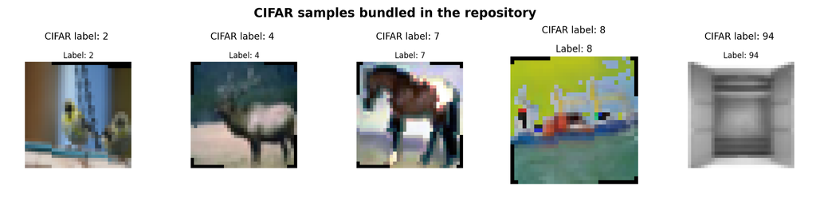

Figure 1: CIFAR sample exports stored in `data/images/` for local visualisation only. The number in the filename is the CIFAR label id.

```python
sample_files = sorted(DATA_IMAGES.glob("sample_*.png"))

if sample_files:
    fig, axes = plt.subplots(1, len(sample_files), figsize=(14, 3))
    if len(sample_files) == 1:
        axes = [axes]
    for ax, img_path in zip(axes, sample_files):
        ax.imshow(Image.open(img_path))
        label = img_path.stem.replace("sample_", "")
        ax.set_title(f"CIFAR label: {label}", fontsize=9)
        ax.axis("off")
    plt.suptitle("CIFAR samples bundled in the repository", fontweight="bold")
    plt.show()
else:
    print("No sample image found in data/images/")
```

To make tokenisation tangible, we use one of these local CIFAR sample exports as a purely illustrative input, split it into the same 16×16 patch grid used by the ViT, and display what a random 75 % MAE mask looks like:

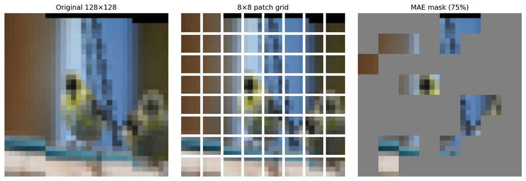

Figure 2: Left: the original image. Center: the 8×8 patch grid used by the Teacher (128/16 = 8 patches per side). Right: a random 75 % MAE-style mask applied at the *patch* level — this is the actual input the SSL Teacher is trained to reconstruct.

```python
rng = np.random.default_rng(seed=0)
patch = 16
img_path = sample_files[0] if sample_files else None

if img_path is not None:
    raw = np.asarray(Image.open(img_path).convert("RGB"))

    # Some sample_*.png were generated via matplotlib and may include
    # white margins/title text ("Label: ..."). We crop back to the
    # dense image area before tokenisation visualisation.
    non_white = (raw < 245).any(axis=2)
    row_density = non_white.mean(axis=1)
    col_density = non_white.mean(axis=0)

    dense_rows = np.where(row_density > 0.50)[0]
    dense_cols = np.where(col_density > 0.50)[0]

    if dense_rows.size > 0 and dense_cols.size > 0:
        y0, y1 = dense_rows[0], dense_rows[-1] + 1
        x0, x1 = dense_cols[0], dense_cols[-1] + 1
        cropped = raw[y0:y1, x0:x1]
        if cropped.size > 0:
            raw = cropped

    img = np.asarray(Image.fromarray(raw).resize((128, 128)))
    H, W, _ = img.shape
    nh, nw = H // patch, W // patch

    grid = img.copy()
    for i in range(1, nh):
        grid[i * patch - 1 : i * patch + 1, :, :] = 255
    for j in range(1, nw):
        grid[:, j * patch - 1 : j * patch + 1, :] = 255

    n_tokens = nh * nw
    keep_mask = rng.random(n_tokens) >= 0.75
    masked = img.copy()
    for k, keep in enumerate(keep_mask):
        if keep:
            continue
        i, j = divmod(k, nw)
        masked[i * patch : (i + 1) * patch, j * patch : (j + 1) * patch] = 128

    fig, axes = plt.subplots(1, 3, figsize=(12, 4))
    for ax, im, title in zip(
        axes,
        [img, grid, masked],
        ["Original 128×128", f"{nh}×{nw} patch grid", "MAE mask (75%)"],
    ):
        ax.imshow(im)
        ax.set_title(title)
        ax.axis("off")
    plt.tight_layout()
    plt.show()
```

## 4.3 Training pipeline

The layer-wise learning-rate policy is intentionally asymmetric across stages. For the supervised ViT phase (Teacher with REPA, then Student distillation), we use an **increasing** layer-wise schedule: deeper blocks and the head get larger updates, which helps adapt high-level semantic features to the target classes. For the SSL MAE Teacher stage, we use a **decreasing** schedule so earlier layers receive comparatively larger updates, encouraging robust local texture and patch-level representations before semantic fine-tuning.

Running the full pipeline from the project root:

```bash
python -m src.train.train_teacher_SSL  --dataset imagenet --mask_ratio 0.75
python -m src.train.train_teacher      --dataset imagenet \
    --resume-from checkpoints/imagenet/ssl_teacher/ssl_teacher_best.pth
python -m src.train.train_student      --dataset imagenet --rho 0.7 \
    --run_name tiny_dynamic_vit
```

### 4.3.1 Stage 1 — MAE reconstructions

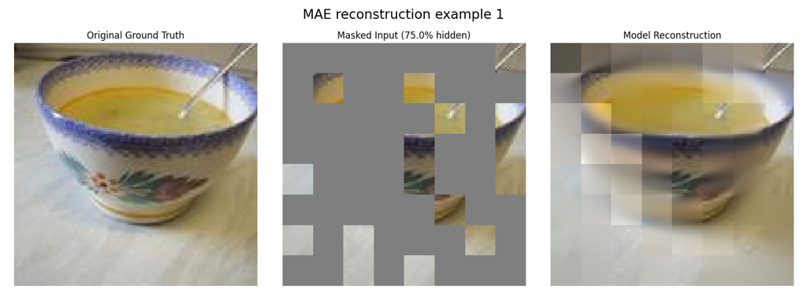

Figure 3: Stage 1: reconstructions produced by the SSL Teacher on held-out 128×128 ImageNet images. For each row: **left** = original image, **center** = the 75 %-masked input fed to the ViT, **right** = reconstructed image assembled from the predicted patch pixels.

```python
ssl_vis_dir = LOGS / "ssl_teacher" / "visualizations"
if ssl_vis_dir.exists():
    for i, p in enumerate(sorted(ssl_vis_dir.glob("ssl_reconstruction_*.png"))[:3]):
        show(p, figsize=(12, 4), title=f"MAE reconstruction example {i + 1}")
else:
    print(f"[missing] {ssl_vis_dir}")
```

The MAE reconstruction loss and learning-rate schedule over SSL pre-training:

```python
ssl_graphs = LOGS / "ssl_teacher" / "graphs"
show(ssl_graphs / "ssl_loss_curve.png", figsize=(10, 4), title="SSL reconstruction loss")
show(ssl_graphs / "ssl_lr_curve.png",  figsize=(10, 4), title="SSL learning-rate schedule")
```

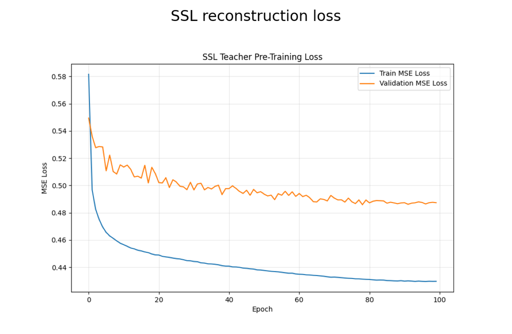

(a) MAE training curves: (left) reconstruction loss, (right) learning-rate schedule.

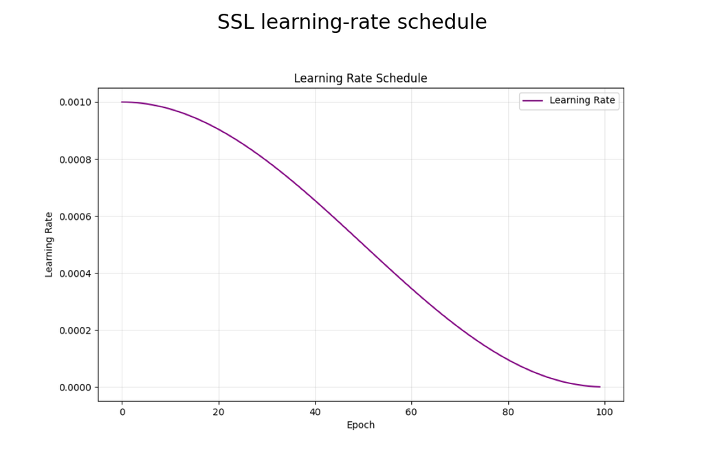

(b)

Figure 4

### 4.3.2 Stage 2 — Teacher with REPA

```python
teacher_graphs = LOGS / "teacher" / "Teacher_ViT_imagenet1K-graphs"
show(teacher_graphs / "loss_curve.png",     figsize=(10, 4), title="Teacher training & validation loss")
show(teacher_graphs / "accuracy_curve.png", figsize=(10, 4), title="Teacher training & validation accuracy")
show(teacher_graphs / "lr_curve.png",       figsize=(10, 4), title="Teacher learning-rate schedule (increasing LLRD)")
```

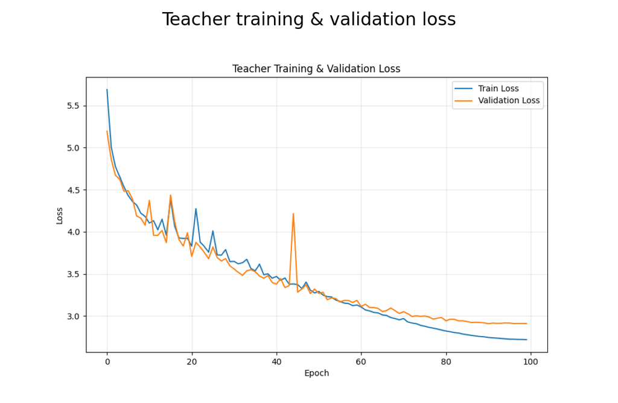

(a) Stage 2: Teacher fine-tuning (supervised + REPA) on ImageNet-1k 128×128.

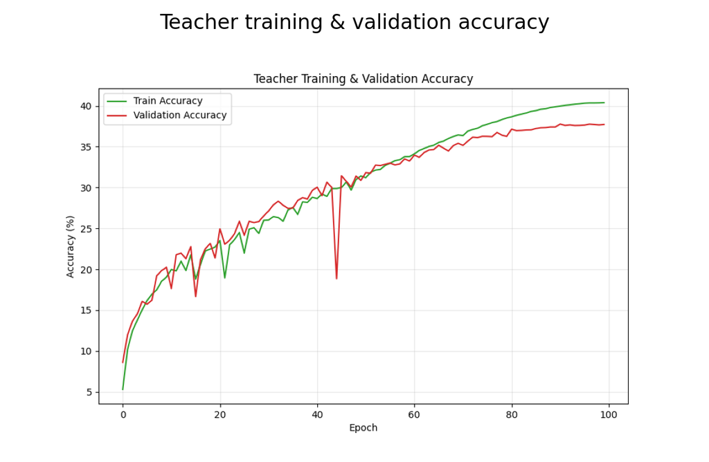

(b)

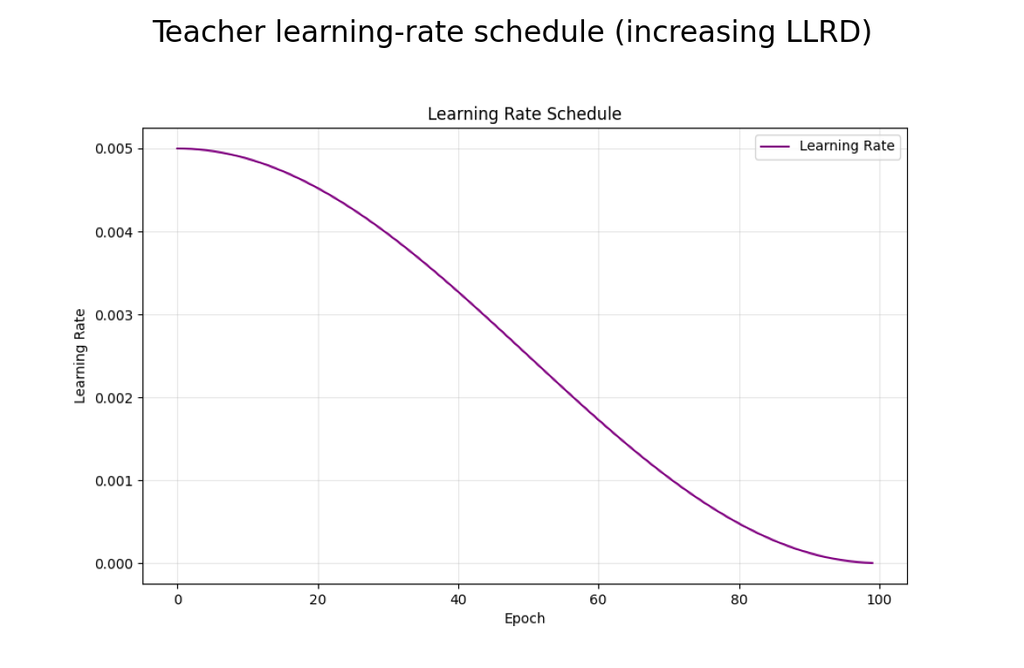

(c)

Figure 5

A raw 1000×1000 confusion matrix is available on disk (`logs/imagenet/teacher/Teacher_ViT_imagenet1K-graphs/confusion_matrix.png`) but is not rendered here: at ImageNet-1k scale the individual cells collapse to less than a pixel and the off-diagonal confusions are dwarfed by the diagonal. A readable top-20 variant is displayed in Figure 10 of the Results section, where the Teacher and the Student are compared side-by-side.

### 4.3.3 Stage 3 — Student DynamicViT

The Student is optimised with four simultaneous objectives. Their individual evolution across training is logged separately:

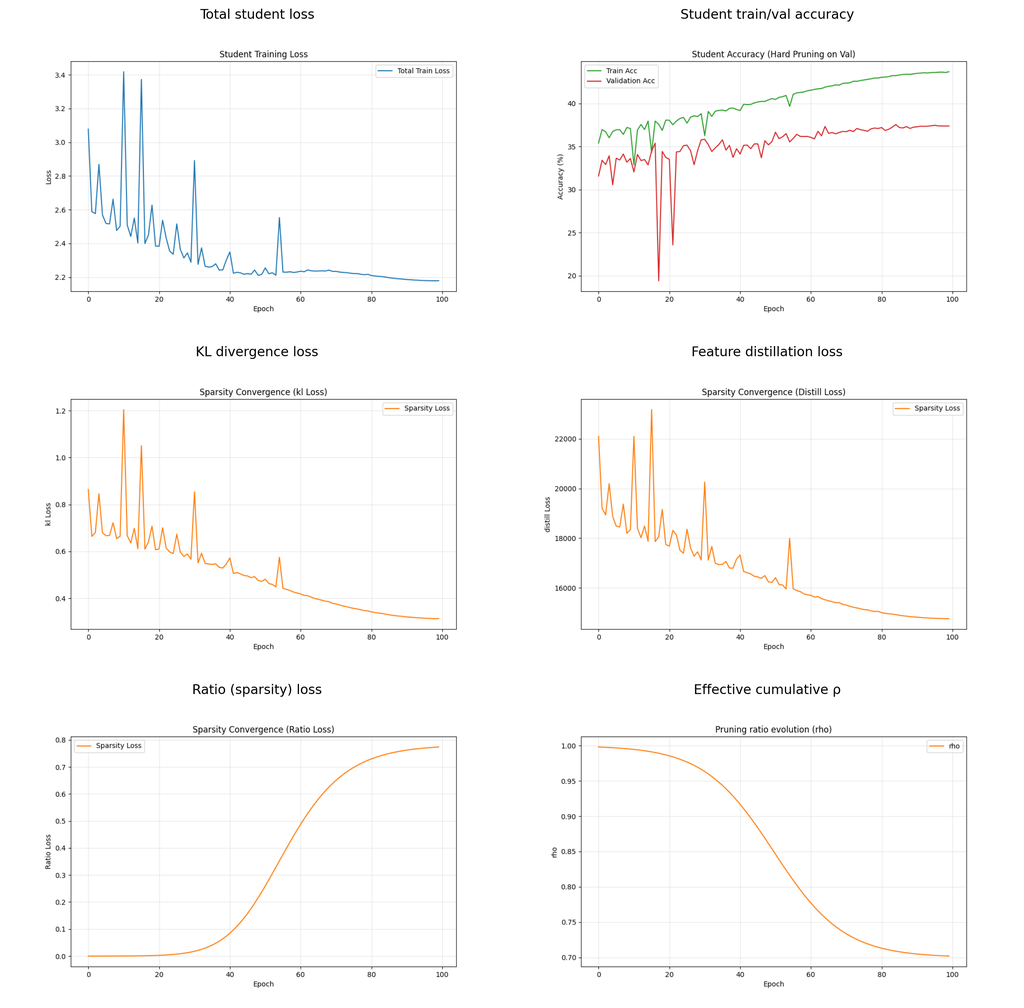

Figure 6: Stage 3: Student training curves. Top row: total loss and accuracy. Middle row: KL divergence with the Teacher logits (left) and feature-distillation loss on surviving tokens (right). Bottom row: ratio (sparsity) loss and the *effective* cumulative keep rate ρ produced by the Predictor-LG modules.

```python
student_graphs = LOGS / "student" / "Student_ViT_imagenet1k-graphs"

panels = [
    ("student_loss_curve.png",      "Total student loss"),
    ("student_accuracy_curve.png",  "Student train/val accuracy"),
    ("student_kl_loss.png",         "KL divergence loss"),
    ("student_distill_loss.png",    "Feature distillation loss"),
    ("student_ratio_loss.png",      "Ratio (sparsity) loss"),
    ("student_rho.png",             "Effective cumulative ρ"),
]

fig, axes = plt.subplots(3, 2, figsize=(12, 12))
for ax, (fname, title) in zip(axes.ravel(), panels):
    p = student_graphs / fname
    if p.exists():
        ax.imshow(Image.open(p))
    ax.set_title(title)
    ax.axis("off")
plt.tight_layout()
plt.show()
```

```python
prune_dir = LOGS / "pruning_visualizations"
if prune_dir.exists():
    for i, p in enumerate(sorted(prune_dir.glob("pruning_vis_*.png"))[:3]):
        show(p, figsize=(14, 5), title=f"Pruning visualisation — batch {i + 1}")
```

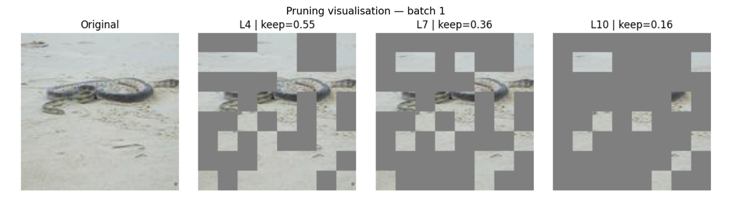

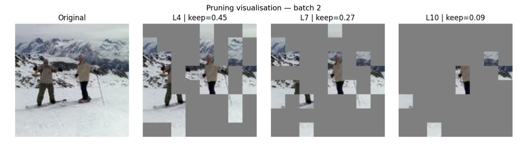

(b)

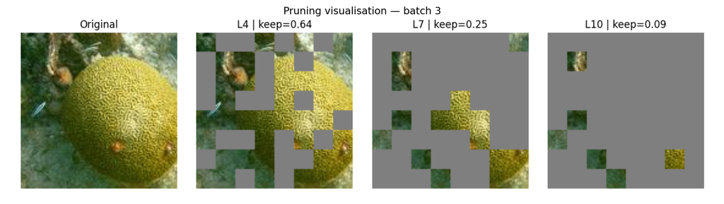

(c)

Figure 7

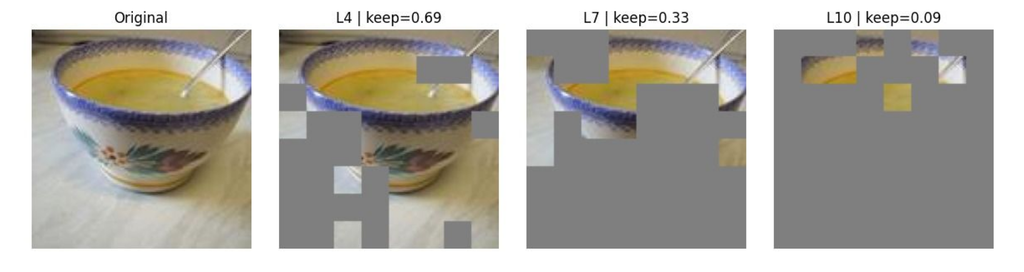

```python
show(LOGS / "student" / "pruning" / "pruning_evolution.jpeg", figsize=(12, 4))
```

## 4.4 Configuration used

Stage-wise hyper-parameters live under `configs/`. Committing them to Git guarantees that each run is reproducible from a single file. Below is a programmatic dump of the ImageNet configuration, these are the exact numbers that produced the figures above:

```python
import runpy
cfg_raw = runpy.run_path(str(ROOT / "configs" / "train_imagenet1k.py"))
cfg = {k: v for k, v in cfg_raw.items() if not k.startswith("_") and not callable(v)}

categories = {
    "Architecture": ["d_model", "n_classes", "img_size", "patch_size", "n_channels", "n_heads", "n_layers"],
    "Optimisation": ["batch_size", "epochs", "alpha", "layer_decay"],
    "DynamicViT":   ["pruning_index", "rho", "rho_init", "steepness",
                     "lambda_class", "lambda_kl", "lambda_ratio", "lambda_distill"],
    "Normalisation": ["mean_norm_imagenet", "std_norm_imagenet"],
    "Fine-tuning":  ["finetuning", "rank"],
    "REPA":         ["lambda_repa"],
}

rows = []
for section, keys in categories.items():
    for k in keys:
        if k in cfg:
            rows.append({"section": section, "parameter": k, "value": str(cfg[k])})

pd.DataFrame(rows)
```

Table 1: Configuration `configs/train_imagenet1k.py` (ImageNet-1k 128×128).

|  | section | parameter | value |
| --- | --- | --- | --- |
| 0 | Architecture | d_model | 96 |
| 1 | Architecture | n_classes | 1000 |
| 2 | Architecture | img_size | (128, 128) |
| 3 | Architecture | patch_size | (16, 16) |
| 4 | Architecture | n_channels | 3 |
| 5 | Architecture | n_heads | 4 |
| 6 | Architecture | n_layers | 12 |
| 7 | Optimisation | batch_size | 256 |
| 8 | Optimisation | epochs | 100 |
| 9 | Optimisation | alpha | 0.001 |
| 10 | DynamicViT | pruning_index | [4, 7, 10] |
| 11 | DynamicViT | rho | 0.7 |
| 12 | DynamicViT | rho_init | 1 |
| 13 | DynamicViT | steepness | 10.0 |
| 14 | DynamicViT | lambda_class | 1 |
| 15 | DynamicViT | lambda_kl | 1 |
| 16 | DynamicViT | lambda_ratio | 0.5 |
| 17 | DynamicViT | lambda_distill | 2 |
| 18 | Normalisation | mean_norm_imagenet | [0.485, 0.456, 0.406] |
| 19 | Normalisation | std_norm_imagenet | [0.229, 0.224, 0.225] |
| 20 | Fine-tuning | finetuning | LORA |
| 21 | Fine-tuning | rank | 4 |
| 22 | REPA | lambda_repa | 2.0 |

Secrets (Hugging Face tokens, data paths) are loaded at runtime from a local `.env` file through `python-dotenv` and are **never** committed to Git.

## 4.5 Reproducibility of our code and experiments

We followed the main principles of reproducibility in scientific research for Machine Learning:

## 4.6 Results

Final Teacher vs. Student comparison, aggregated by the `compare_st-te.py` script:

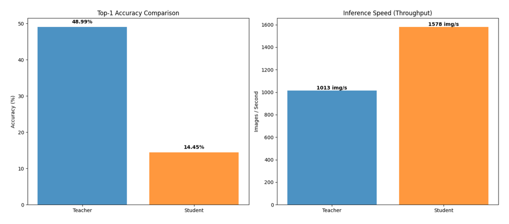

```python
show(LOGS / "evaluation_results" / "compare_performance.png", figsize=(12, 5))
```

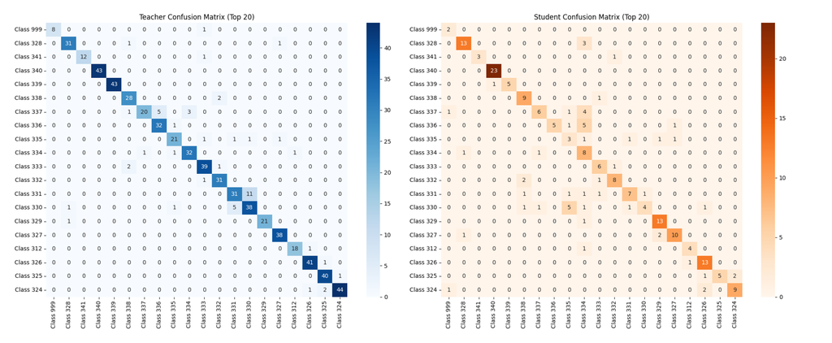

```python
show(LOGS / "evaluation_results" / "compare_confusion_matrices.png", figsize=(14, 5))
```

To give a self-contained high-level summary, the table below consolidates the per-stage outputs available in the repo:

```python
artefacts = [
    ("Stage 1 — SSL MAE", "checkpoint",   "checkpoints/public/imagenet/d128patch16/teacher_SSL/d_model128.pth"),
    ("Stage 1 — SSL MAE", "reconstructions", "logs/imagenet/ssl_teacher/visualizations/ssl_reconstruction_*.png"),
    ("Stage 1 — SSL MAE", "training curves", "logs/imagenet/ssl_teacher/graphs/ssl_*.png"),
    ("Stage 2 — Teacher", "checkpoint",   "checkpoints/public/imagenet/d128patch16/teacher/teacher_d128patch16.pth"),
    ("Stage 2 — Teacher", "training curves", "logs/imagenet/teacher/Teacher_ViT_imagenet1K-graphs/*.png"),
    ("Stage 3 — Student", "checkpoint",   "checkpoints/public/imagenet/d128patch16/student/student_epoch_120.pth"),
    ("Stage 3 — Student", "training curves", "logs/imagenet/student/Student_ViT_imagenet1k-graphs/student_*.png"),
    ("Stage 3 — Student", "pruning maps", "logs/imagenet/pruning_visualizations/pruning_vis_*.png"),
    ("Evaluation",        "Teacher vs Student", "logs/imagenet/evaluation_results/compare_*.png"),
]
pd.DataFrame(artefacts, columns=["stage", "kind", "path"])
```

Table 2: Key artefacts produced by each stage, all tracked in Git and used to build this page.

|  | stage | kind | path |
| --- | --- | --- | --- |
| 0 | Stage 1 — SSL MAE | checkpoint | checkpoints/public/imagenet/d128patch16/teache... |
| 1 | Stage 1 — SSL MAE | reconstructions | logs/imagenet/ssl_teacher/visualizations/ssl_r... |
| 2 | Stage 1 — SSL MAE | training curves | logs/imagenet/ssl_teacher/graphs/ssl_*.png |
| 3 | Stage 2 — Teacher | checkpoint | checkpoints/public/imagenet/d128patch16/teache... |
| 4 | Stage 2 — Teacher | training curves | logs/imagenet/teacher/Teacher_ViT_imagenet1K-g... |
| 5 | Stage 3 — Student | checkpoint | checkpoints/public/imagenet/d128patch16/studen... |
| 6 | Stage 3 — Student | training curves | logs/imagenet/student/Student_ViT_imagenet1k-g... |
| 7 | Stage 3 — Student | pruning maps | logs/imagenet/pruning_visualizations/pruning_v... |
| 8 | Evaluation | Teacher vs Student | logs/imagenet/evaluation_results/compare_*.png |

# 5 Inference on a custom dataset (for new experiments)

**Note**

This section documents the *contract* that a user must respect to push a new image through the trained Student. Because Quarto renders this page in a CI environment without a GPU, we do **not** execute the forward pass live — we describe the pre-processing, checkpoint loading and inference code a user can paste into a notebook.

## 5.1 Input data specification and output format

- **Input.** A single image (PIL, NumPy or Torch tensor) with three RGB channels, **any** resolution. The preprocessing pipeline will resize it to 128×128 and standardise it with the ImageNet statistics used during training.
- **Output.** A Python dictionary:
  - `logits`: `torch.Tensor` of shape `(1, 1000)` — raw class scores over ImageNet-1k.
  - `top5`: a list of `(class_id, probability)` pairs, sorted by probability, with class ids matching the ImageNet-1k ordering.
  - `keep_masks`: a list of three binary masks (one per pruning index) of shape `(1, N)` with $N = (128/p)^2$ tokens. Useful to visualise which regions the Student actually looked at.

## 5.2 Pre-processing pipeline

The same `torchvision` transforms used at test time (see `data/load/imagenet_loader.py`) must be applied:

```python
from torchvision import transforms as T

IMAGE_SIZE = 128
MEAN = [0.485, 0.456, 0.406]
STD  = [0.229, 0.224, 0.225]

preprocess = T.Compose([
    T.Resize((IMAGE_SIZE, IMAGE_SIZE)),
    T.ToTensor(),
    T.Normalize(mean=MEAN, std=STD),
])
```

## 5.3 Running a forward pass

```python
import torch
from PIL import Image

from src.models.dynamicViT import DynamicVisionTransformer

# 1. Load the public Student checkpoint shipped with this repo.
ckpt_path = "checkpoints/public/imagenet/d128patch16/student/student_epoch_120.pth"
ckpt = torch.load(ckpt_path, map_location="cpu")

# 2. Rebuild the exact architecture the checkpoint was trained with.
#    Hyperparameters are persisted inside the .pth by train_student.py.
student = DynamicVisionTransformer(**ckpt["hyperparameters"])
student.load_state_dict(
    {k.replace("_orig_mod.", ""): v for k, v in ckpt["model_state_dict"].items()},
    strict=False,
)
student.eval()

# 3. Run on a new image.
img = Image.open("data/images/sample_7.png").convert("RGB")
x   = preprocess(img).unsqueeze(0)                 # (1, 3, 128, 128)

with torch.inference_mode():
    logits, _feats, keep_masks, _scores = student(x)

probs   = torch.softmax(logits, dim=-1)
top5_p, top5_i = probs.topk(5)
print(list(zip(top5_i[0].tolist(), top5_p[0].tolist())))
```

The returned `keep_masks` can be overlaid on the input to reproduce the style of visualisation shown in Figure 7.

## 5.4 Running the same inference in Docker

Docker packages the code, Python dependencies and runtime setup in an isolated container, so the forward-pass demo runs the same way across machines without local environment drift. In this repository, `Dockerfile` and `compose.yaml` are configured to execute the Student inference workflow reproducibly from a clean environment, which is useful for quick validation or sharing the demo setup with teammates.

# 6 CI/CD

## 6.1 GitHub Actions workflow

Two workflows live under `.github/workflows/`:

- **`quarto.yml`** — renders this report with Quarto on every push to the `reprod` branch, then publishes the resulting static site to the `gh-pages` branch. The build installs dependencies with `uv sync`, so the CI uses the exact same lockfile as contributors.
- **`ruff.yml`** — runs the `ruff` linter/formatter on every push and PR to `main`, using the configuration in `ruff.toml` (88-char line length, double quotes, imports sorted).

## 6.2 Tests

The `src/test/` directory acts as a small integration-test suite that can be run manually after training:

- `parameters_computing.py` — loads both checkpoints and computes the exact FLOPs, MACs and parameter counts with `calflops`.
- `compare_st-te.py` — evaluates Teacher and Student on the ImageNet-1k test split, then regenerates the performance and confusion-matrix figures displayed above.
- `test_SSLteacher.py` — reports MSE, MAE and PSNR for the MAE Teacher and re-renders the `ssl_reconstruction_*.png` visualisations.

A light-weight `pytest` entry point is declared in `pyproject.toml` (`[scripts] test = "pytest"`) for future unit tests targeting the model building blocks.

# 7 References

Dosovitskiy, Alexey, Lucas Beyer, Alexander Kolesnikov, et al. 2021. “An Image Is Worth 16x16 Words: Transformers for Image Recognition at Scale.” *International Conference on Learning Representations (ICLR)*. https://arxiv.org/abs/2010.11929.

He, Kaiming, Xinlei Chen, Saining Xie, Yanghao Li, Piotr Dollár, and Ross B. Girshick. 2022. “Masked Autoencoders Are Scalable Vision Learners.” *IEEE/CVF Conference on Computer Vision and Pattern Recognition (CVPR)*. https://arxiv.org/abs/2111.06377.

Hinton, Geoffrey, Oriol Vinyals, and Jeff Dean. 2015. “Distilling the Knowledge in a Neural Network.” *NeurIPS Deep Learning and Representation Learning Workshop*. https://arxiv.org/abs/1503.02531.

Oquab, Maxime, Timothée Darcet, Théo Moutakanni, et al. 2024. “DINOv2: Learning Robust Visual Features Without Supervision.” *Transactions on Machine Learning Research*. https://arxiv.org/abs/2304.07193.

Rao, Yongming, Wenliang Zhao, Benlin Liu, Jiwen Lu, Jie Zhou, and Cho-Jui Hsieh. 2021. “DynamicViT: Efficient Vision Transformers with Dynamic Token Sparsification.” *CoRR* abs/2106.02034. https://arxiv.org/abs/2106.02034.